# laboratorio # 2

Heberto Jose Alegre Ordoñez

20 de marzo de 2019

Primero se carga el archivo para ello utilizamos la siguiente linea de código

```r
# Verificamos la ruta donde se encuentra el archivo
getwd()
```

```
## [1] "C:/Users/Toshiba/Documents/Heberto Alegre/GALILEO/Primer trimestre/Estadística/laboratorio"
```

```r
# Posteriormente lo abrimos

lab2<-read.csv("demandaBicis.csv", T, ",", encoding = "UTF-8")
head(lab2)
```

```
##   instant     dteday season yr mnth hr holiday weekday workingday
## 1       1 2011-01-01      1  0    1  0       0       6          0
## 2       2 2011-01-01      1  0    1  1       0       6          0
## 3       3 2011-01-01      1  0    1  2       0       6          0
## 4       4 2011-01-01      1  0    1  3       0       6          0
## 5       5 2011-01-01      1  0    1  4       0       6          0
## 6       6 2011-01-01      1  0    1  5       0       6          0
##   weathersit temp  atemp  hum windspeed casual registered cnt
## 1          1 0.24 0.2879 0.81    0.0000      3         13  16
## 2          1 0.22 0.2727 0.80    0.0000      8         32  40
## 3          1 0.22 0.2727 0.80    0.0000      5         27  32
## 4          1 0.24 0.2879 0.75    0.0000      3         10  13
## 5          1 0.24 0.2879 0.75    0.0000      0          1   1
## 6          2 0.24 0.2576 0.75    0.0896      0          1   1
```

```r
library(dplyr)
```

Usando sus concimientos de R, responda las siguientes preguntas:

1. ¿Que mes es el que tiene la mayor demanda? Para ello utilizamos la siguiente línea de código

```r
lab2.m<-lab2%>%
  select(mnth, casual, registered)

meses<-lab2.m%>%
  group_by(mnth) %>%
  summarise(registro=sum(casual, registered))%>%
  arrange(desc(registro))

  head(meses)
```

```
## # A tibble: 6 x 2
##    mnth registro
##   <int>    <int>
## 1     8   351194
## 2     6   346342
## 3     9   345991
## 4     7   344948
## 5     5   331686
## 6    10   322352
```

**El mes de agosto es el que presenta la mayor cantidad de registros.**

2. ¿Que rango de hora es la de mayor demanda?

```r
lab2.h<-lab2%>%
  select(hr, casual, registered)

hora<-lab2.h%>%
  group_by(hr)%>%
  summarise(registro=sum(casual, registered))%>%
  arrange(desc(registro))

head(hora)
```

```
## # A tibble: 6 x 2
##      hr registro
##   <int>    <int>
## 1    17   336860
## 2    18   309772
## 3     8   261001
## 4    16   227748
## 5    19   226789
## 6    13   184919
```

**La hora que más registros totales presenta es la 17**

3. ¿Que temporada es la mas alta?

```r
lab2.s<-lab2%>%
  select(season, casual, registered)

estacion<-lab2.s%>%
  group_by(season)%>%
  summarise(registro=sum(casual, registered))%>%
  arrange(desc(registro))

head(estacion)
```

```
## # A tibble: 4 x 2
##   season registro
##    <int>    <int>
## 1      3  1061129
## 2      2   918589
## 3      4   841613
## 4      1   471348
```

**El otoño es la estación que más restistros presenta con una cantidad de 1061129**

4. ¿A que temperatura baja la demanda?

```r
lab2.t<-lab2%>%
  select(temp, casual, registered)

temperatura<-lab2.t%>%
  group_by(temp)%>%
  summarise(registro=sum(casual, registered))%>%
  arrange(registro)

head(temperatura)
```

```
## # A tibble: 6 x 2
##    temp registro
##   <dbl>    <int>
## 1  1         294
## 2  0.08      480
## 3  0.98      539
## 4  0.04      570
## 5  0.06      672
## 6  0.02      712
```

** La temperatura que presenta menor demanda es la 100F con 294 registros** 5. ¿A que humedad baja la demanda?

```r
lab2.hu<-lab2%>%
  select(hum, casual, registered)

humedad<-lab2.hu%>%
  group_by(hum)%>%
  summarise(registro=sum(casual, registered))%>%
  arrange(registro)

head(humedad)
```

```
## # A tibble: 6 x 2
##     hum registro
##   <dbl>    <int>
## 1  0.13       17
## 2  0.12       29
## 3  0.14       38
## 4  0.97       64
## 5  0.08       77
## 6  0.1       107
```

**La humedad relativa que presenta menor cantidad de registros es el 13%**

6. ¿Que condiciones serian ideales para nuestra demanda?

En base a las conciciones definicadas anteriormente, los valores de las tablas sería de:

```r
#Primero determinamos la temperatura de mayor registro

temperatura<-lab2.t%>%
  group_by(temp)%>%
  summarise(registro=sum(casual, registered))%>%
  arrange(desc(registro))

head(temperatura)
```

```
## # A tibble: 6 x 2
##    temp registro
##   <dbl>    <int>
## 1  0.7    177298
## 2  0.72   163449
## 3  0.74   161587
## 4  0.66   156204
## 5  0.64   154985
## 6  0.6    149905
```

```r
# La humedad relativa con mayor registro sería

humedad<-lab2.hu%>%
  group_by(hum)%>%
  summarise(registro=sum(casual, registered))%>%
  arrange(desc(registro))

head(humedad)
```

```
## # A tibble: 6 x 2
##     hum registro
##   <dbl>    <int>
## 1  0.83    93265
## 2  0.55    86206
## 3  0.46    79253
## 4  0.66    76920
## 5  0.62    76125
## 6  0.88    75604
```

```r
Descripcion <- c("Mes", "Estación", "hora", "Temperatura", "Humedad relativa")
Resultado<-c("Agosto", "Otoño","17 h", "70 F", "83 %" )
Ideal<- cbind(Descripcion, Resultado)
Ideal
```

```
##      Descripcion        Resultado
## [1,] "Mes"              "Agosto"
## [2,] "Estación"         "Otoño"
## [3,] "hora"             "17 h"
## [4,] "Temperatura"      "70 F"
## [5,] "Humedad relativa" "83 %"
```

7. Realice una gráfica de la densidad de temperatura.

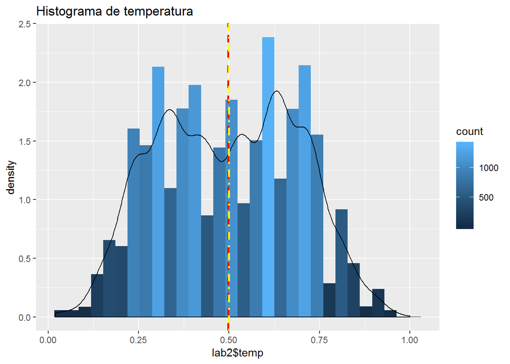

```r
library(ggplot2)
ggplot(data=lab2, mapping=aes(x=lab2$temp))+
  geom_histogram(aes(y=..density.., fill=..count..))+
  ggtitle("Histograma de temperatura")+
  geom_density()+
  geom_vline(xintercept = mean(lab2$temp), color = "red", linetype = "dashed", size = 1)+
  geom_vline(xintercept=median(lab2$temp), color = "yellow", linetype = 4, size = 1)
```

8. Con una gráfica explique en que temporada hubieron mas rentas de bicicletas.

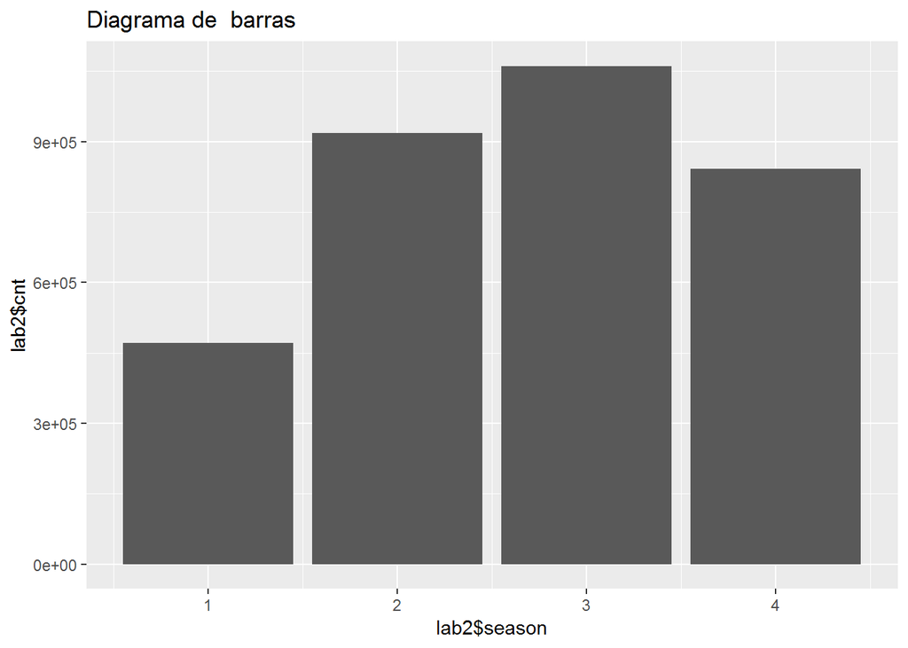

```r
ggplot(data=lab2, mapping = aes(x=lab2$season, y=lab2$cnt))+
  geom_bar(stat="identity")+
  ggtitle("Diagrama de  barras")
```

**Como lo muestra el diagrama anterior de barras, la estación que más registros presenta es el otoño**

En esta sección se muestra las cantidades exactas:

```r
barras<-lab2%>%
  select(season, registered, casual)%>%
  group_by(season)%>%
  summarise(total=sum(registered, casual))%>%
  arrange(total)

head(barras)
```

```
## # A tibble: 4 x 2
##   season   total
##    <int>   <int>
## 1      1  471348
## 2      4  841613
## 3      2  918589
## 4      3 1061129
```

9. Con una gráfica, que temperatura en que temporada producen una mayor renta de bicicleteas (Hint: heatmap).

```r
tempe<-lab2%>%
  select(temp, season, cnt)%>%
  group_by(season)%>%
  summarise(total=sum(cnt))

head(tempe)
```

```
## # A tibble: 4 x 2
##   season   total
##    <int>   <int>
## 1      1  471348
## 2      2  918589
## 3      3 1061129
## 4      4  841613
```

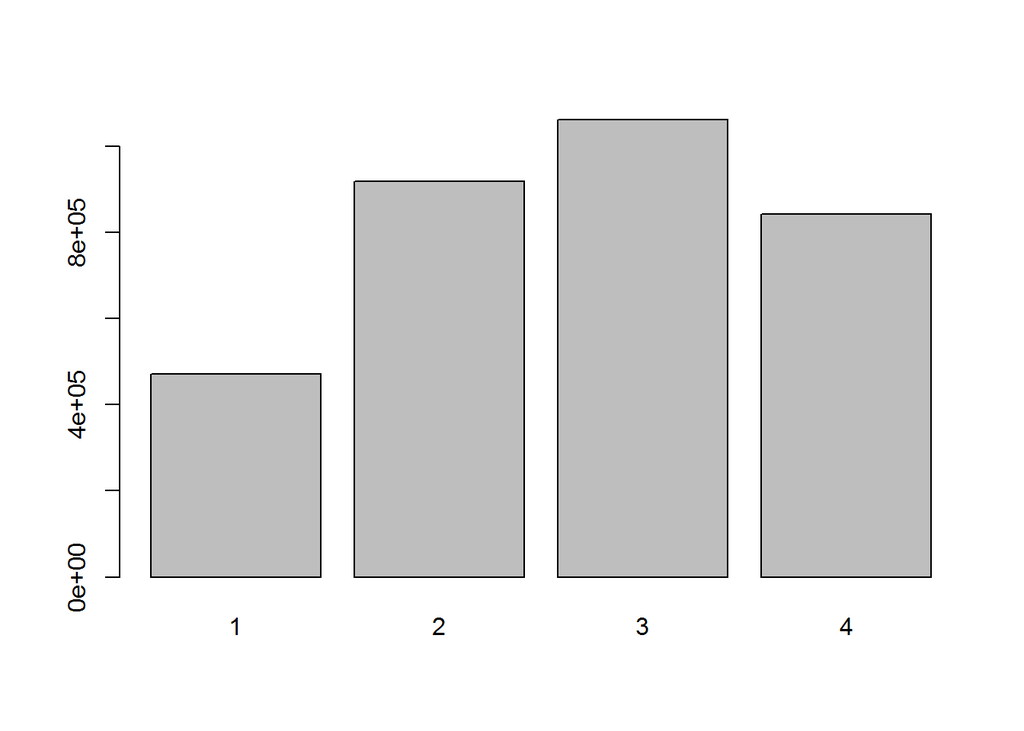

```r
barplot(tempe$total, names.arg=tempe$season)
```

10. Muestre una gráfica de barras de día de la semana por bicicletas rentas, pero muestre en la misma barra cuantas rentas fueron por usuarios casuales y cuentas por usuarios registrados.

```r
barcom<-lab2%>%
  select(weekday, casual, registered) %>%
  group_by(weekday)%>%
  summarise(casual=sum(casual),registro=sum(registered), total=sum(casual, registered))


barcom
```

```
## # A tibble: 7 x 4
##   weekday casual registro  total
##     <int>  <int>    <int>  <int>
## 1       0 140521   303506 444027
## 2       1  70784   384719 455503
## 3       2  57843   411266 469109
## 4       3  57319   415729 473048
## 5       4  61460   423935 485395
## 6       5  78238   409552 487790
## 7       6 153852   323955 477807
```

```r
barcom$weekday
```

```
## [1] 0 1 2 3 4 5 6
```

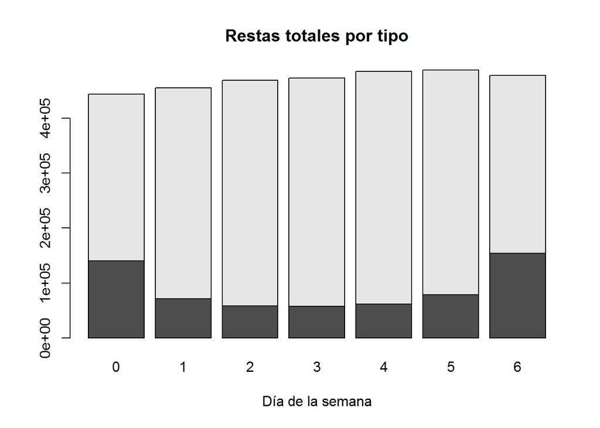

```r
grupo<-t(data.matrix(barcom[2:3]))
barplot(grupo, names.arg = barcom$weekday,
        main = "Restas totales por tipo",
        xlab = "Día de la semana")
```